# An interactive PCA biplot with `ggbiplot` and `plotly` R packages

by: [Valentin Stefan](https://github.com/valentinitnelav)

last update: 2018-08-26

**This post is part of my R notes series**

# 1 What is this about?

Take a usual PCA biplot and make it interactive via the functionality of R packages ggbiplot and [plotly](https://cran.r-project.org/web/packages/plotly/index.html).

These notes build on the PCA example from [An Introduction to Statistical Learning - with Applications in R (James et al. 2013)](https://www-bcf.usc.edu/~gareth/ISL/index.html), using as example the PCA biplot from *FIGURE 10.1. The first two principal components for the USArrests data.*

# 2 Prepare R session

Load R packages:

```r
# Note: intsall `ggtree` from GitHub;
# At the time of writing these notes, ggbiplot was not on CRAN.
# devtools::install_github("vqv/ggbiplot")
library(ggbiplot)
library(plotly)
```

# 3 Run PCA

Run principal components analysis (PCA) and the usual biplot.

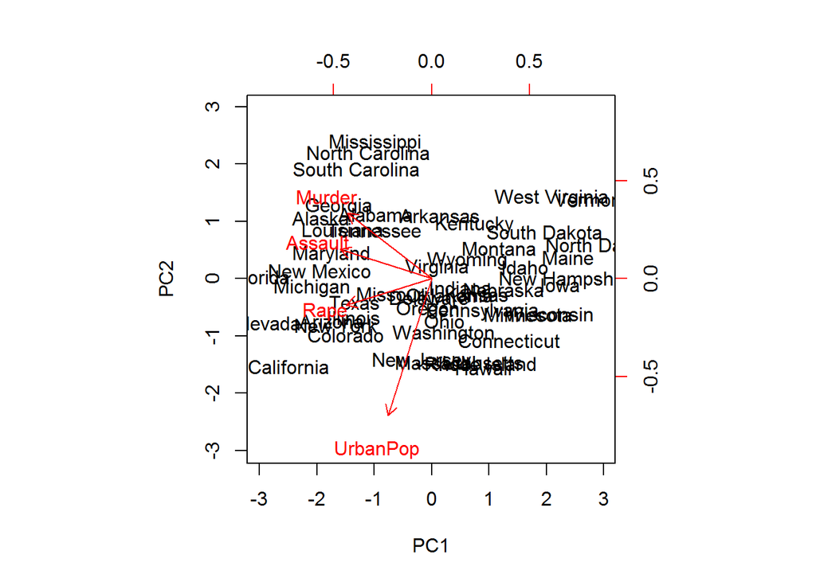

The usual PCA `biplot`

```r
pr.out <- prcomp(USArrests, scale = TRUE)
biplot(pr.out, scale = 0)
```

# 4 Examples with `ggbiplot` & `ggplotly`

## 4.1 Minimal case

First steps with `ggbiplot` & `ggplotly`.

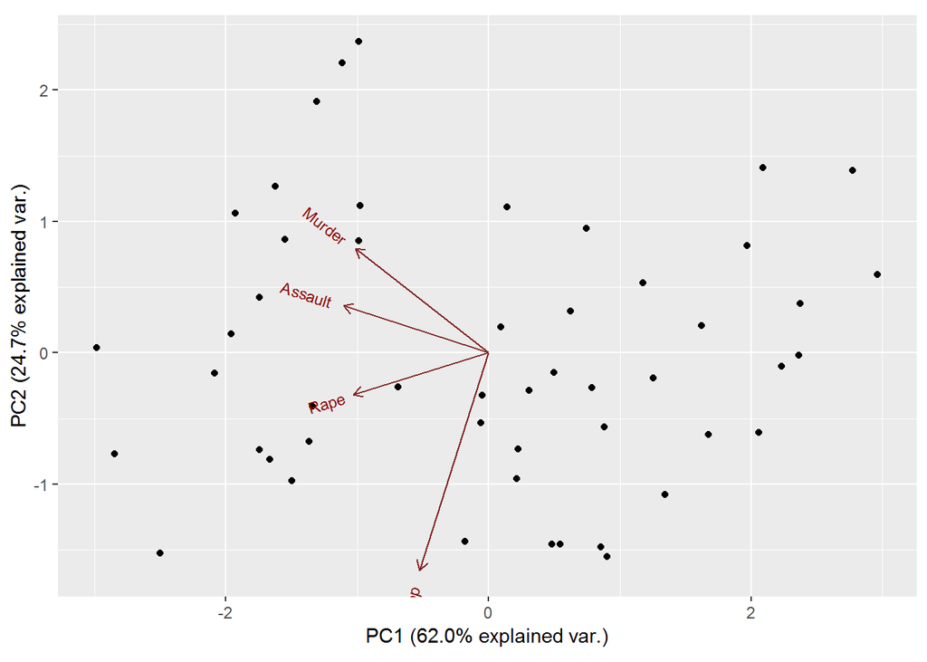

A simple PCA biplot with `ggbiplot`

```r
simple_plot <- ggbiplot(pcobj = pr.out, scale = 0)
simple_plot
```

```r
ggplotly(simple_plot)
```

[interactive chart not shown]

A simple interactive PCA biplot with `plotly` (hover the mouse pointer)

## 4.2 Add color & size

Example of mapping one of the variables (features) into color and size.

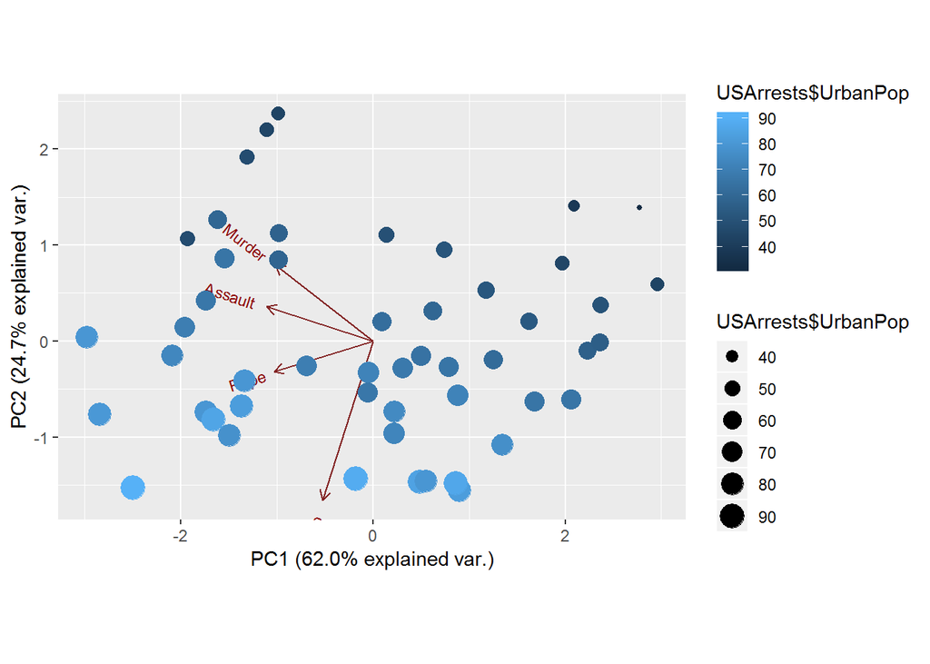

Map urban population feature into color and size

```r
p <- ggbiplot(pcobj = pr.out,
              scale = 0,
              alpha = 0)
p1 <- p + geom_point(aes(color = USArrests$UrbanPop,
                         size  = USArrests$UrbanPop))
p1
```

Take the draft plot from above and make it interactive.

```r
ggplotly(p1)
```

[interactive chart not shown]

Interactive PCA biplot

The two aesthetics will need to be combined in the legend. While this is possible in `ggplot` with using the `guides` function, it will not trickle down to `ggplotly` output. [This SO link](https://stackoverflow.com/q/47383244/5193830) could be interesting to investigate.

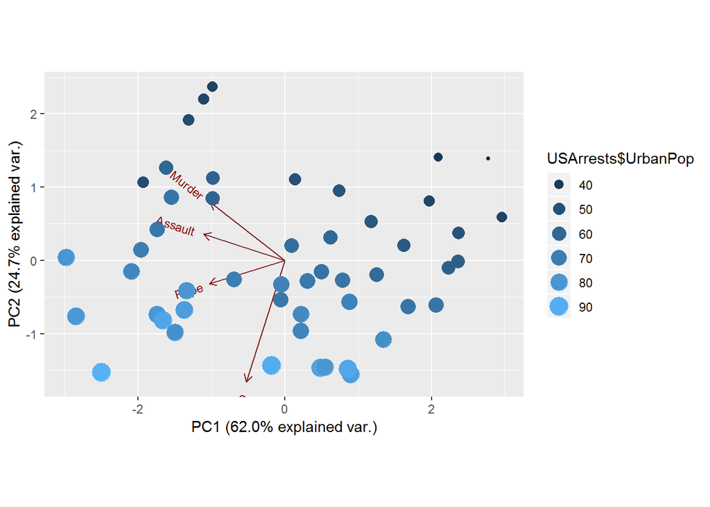

```r
# Combine size and color in legend;
# see https://stackoverflow.com/a/32652899/5193830
p2 <- p1 +
  guides(color = guide_legend(),
         size = guide_legend())
p2
```

```r
# Couldn't find a way yet to make it work with plotly :/
ggplotly(p2)
```

[interactive chart not shown]

If you need to adjust the limits and breaks for the bubbles, use the `scale_` functions. The changes in the legend will also not trickle down to the `ggplotly` output.

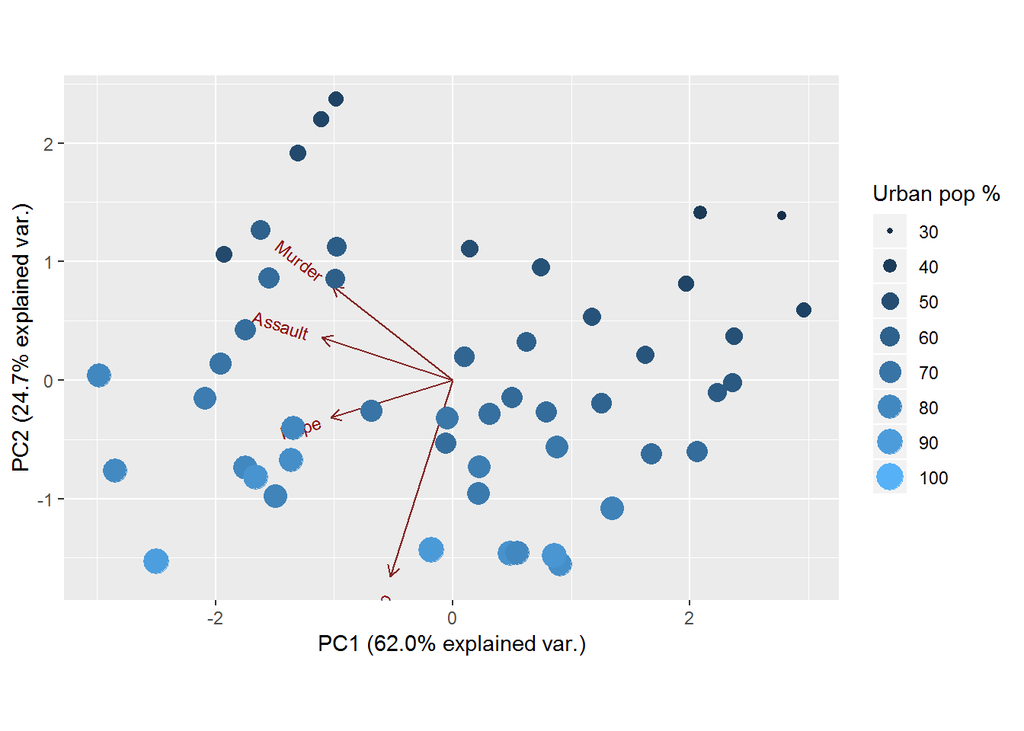

```r
# Combine size and color in legend, adjust the limits and breaks;
# see https://stackoverflow.com/a/32652899/5193830
p2 <- p1 +
  scale_color_continuous("Urban pop %",
                         limits = c(30, 100),
                         breaks = seq(30, 100, by = 10)) +
  scale_size_continuous("Urban pop %",
                        limits = c(30, 100),
                        breaks = seq(30, 100, by = 10)) +
  guides(color = guide_legend(),
         size = guide_legend())
p2
```

```r
# Legend also doesn't pass to plotly :(
ggplotly(p2)
```

[interactive chart not shown]

## 4.3 Custom hover text

Simple example, with adding a single new field in the `plotly` popup.

```r
p3 <- p + geom_point(aes(color = USArrests$UrbanPop,
                         size  = USArrests$UrbanPop,
                         # Text aesthetic will be ignored in `ggplot`,
                         # but will be used for mouse hovering in `ggplotly`.
                         text = paste("Murder:", USArrests$Murder)))
ggplotly(p3)
```

[interactive chart not shown]

Interactive PCA biplot - add a new field in the popup (hover the mouse pointer)

Add more fields in the `plotly` popup. This was inspired from [a plotly example](https://plot.ly/r/text-and-annotations/#custom-hover-text).

```r
p4 <- p + geom_point(aes(color = USArrests$UrbanPop,
                         size  = USArrests$UrbanPop,
                         # Text aesthetic will be ignored in `ggplot`,
                         # but will be used for mouse hovering in `ggplotly`.
                         text = paste("Murder:", USArrests$Murder,
                                      '</br> Assault:', USArrests$Assault,
                                      '</br> UrbanPop:', USArrests$UrbanPop,
                                      '</br> Rape:', USArrests$Rape)))
ggplotly(p4)
```

[interactive chart not shown]

Interactive PCA biplot - use the `</br>` trick to add several fields in the popup (hover the mouse pointer)

A way to automatically add all feature values from the data as fields in the plotly popup.

```r
features <- paste0(c('State', names(USArrests)), ": ")
my_labels <- apply(X = cbind(rownames(USArrests), USArrests),
                   MARGIN = 1,
                   FUN = function(row) paste(paste(features, row),
                                             collapse = "</br>"))
p5 <- p + geom_point(aes(color = USArrests$UrbanPop,
                         size  = USArrests$UrbanPop,
                         # Text aesthetic will be ignored in `ggplot`,
                         # but will be used for mouse hovering in `ggplotly`.
                         text = my_labels))
ggplotly(p5)
```

[interactive chart not shown]

Interactive PCA biplot - add all feature values as fields in the popup (hover the mouse pointer)

# 5 References

Carson Sievert (2018) plotly for R. [link](https://plotly-book.cpsievert.me)

James, G., Witten, D., Hastie, T. and Tibshirani, R., 2013. An introduction to statistical learning (Vol. 112). New York: Springer. [link](https://www-bcf.usc.edu/~gareth/ISL/index.html)

Vincent Q. Vu (2011). ggbiplot: A ggplot2 based biplot. R package version 0.55 [link](http://github.com/vqv/ggbiplot)